# Assessment_1

### Section 6: Visualisations

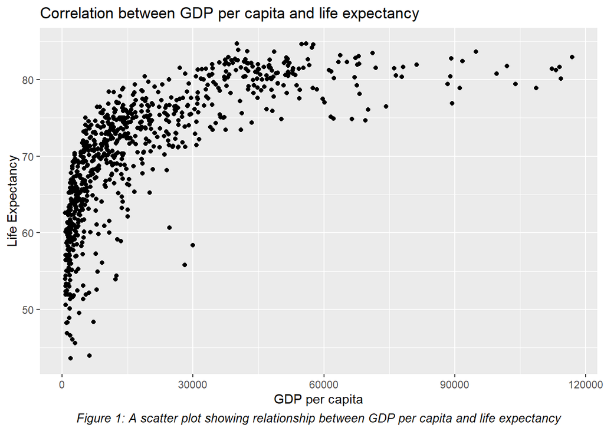

```r
figure_1 <- ggplot(gdp_life_exp_data, aes(x = GDP_per_capita, y = Life_expectancy)) +
  geom_point() +
  labs(title = "Correlation between GDP per capita and life expectancy",
       x = "GDP per capita",
       y = "Life Expectancy",
       caption = "Figure 1: A scatter plot showing relationship between GDP per capita and life expectancy") +
  theme(plot.caption = element_text(size = 10, face = "italic", hjust = 0.5))

figure_1
```

- *As GDP Per capita increases, life expectancy also seems to increase, especially between 0 and 60000 GDP per capita*
- *Life expectancy seems to plateau at approximately 80 years old and 60000 GDP per capita*

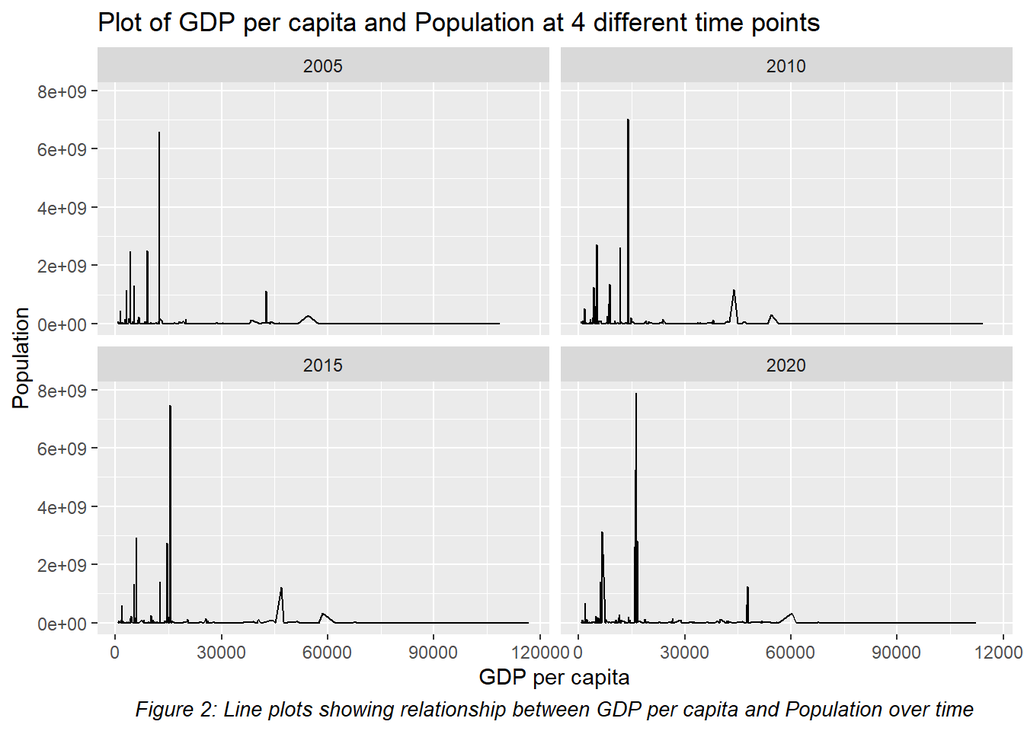

```r
comparison_data <- comparison_data %>%
  mutate(
    Country = as.factor(Country)
  )

figure_2 <- ggplot(comparison_data, aes(x = GDP_per_capita, y = Population)) +
  geom_line() +
  facet_wrap(~Year) +
  labs(title = "Plot of GDP per capita and Population at 4 different time points",
       x = "GDP per capita",
       y = "Population",
       caption = "Figure 2: Line plots showing relationship between GDP per capita and Population over time") +
  theme(plot.caption = element_text(size = 10, face = "italic", hjust = 0.5))

figure_2
```

- *As we move throught the snapshots in time, GDP per capita is increasing slightly evidence by the spikes in population moving slightly further to the right on the x-axis*
- *Population increases with GDP throughout time, shown in the plot by the spikes growing taller on the y-axis through the snapshots in time*